# Session 4 — Assumptions of Linear Regression

Linearity · independence · normality · equal variance · collinearity · Topic 7 · Lab 4

Community Medicine Workshop

## Where we are

- We have a model: `sbp ~ salt_g + age + bmi + sex + residence + education + tobacco + alcohol + phys_act`
- Its p-values and CIs are **only trustworthy if its assumptions are reasonable**
- For each assumption today: **what it means → how to check → what a violation looks like in OUR data → what to do**

# Topic 7 — Assumptions

## The checklist

|  | Assumption | Plain meaning |
| --- | --- | --- |
| **L** | **Linearity** | The mean outcome changes in a straight line with each predictor |
| **I** | **Independence** | One person’s error tells you nothing about another’s |
| **N** | **Normality** of residuals | Residuals are roughly bell-shaped |
| **E** | **Equal variance** (homoscedasticity) | Spread of residuals is the same at every fitted value |
| **M** | **No severe multicollinearity** | Predictors are not near-copies of each other |

Plus a look for **influential points** (a few people driving the result).

## What goes wrong when each fails

| Violation | Main consequence |
| --- | --- |
| Non-linearity | **Biased** β — the line is the wrong shape |
| Non-independence (clusters) | SEs **too small** → CIs too narrow, p too small |
| Non-normal residuals | Usually minor if n is large; matters for small n and prediction intervals |
| Unequal variance | SEs **wrong** (usually too small/large in places); estimates less efficient |
| Multicollinearity | SEs **inflated**, β unstable, even sign flips |

## The one-page panel: `check_model()`

```r
check_model(m, check = c("linearity", "homogeneity", "qq", "outliers"))
```

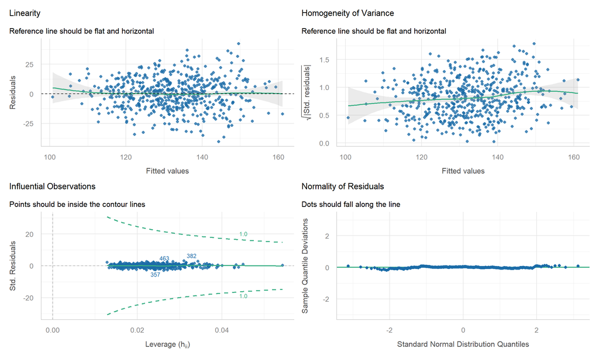

# L — Linearity

## Linearity: what and how

**Means:** each continuous predictor has a **straight-line** relationship with the mean outcome.

**Check:** plot **residuals vs each continuous predictor** (and vs fitted) with a smooth curve — it should be flat.

**Violation looks like:** a curved (U, ∩ or banana-shaped) smooth line in the residual plot.

## In our data: age is slightly curved

```r
cc |>
  mutate(res = resid(m)) |>
  ggplot(aes(age, res)) +
  geom_point(alpha = .3, colour = col_blue) +
  geom_smooth(method = "loess", se = FALSE, colour = col_red, formula = y ~ x) +
  geom_hline(yintercept = 0, linetype = "dashed") +
  labs(x = "Age (years)", y = "Residual (mmHg)")
```

## In our data: age is slightly curved

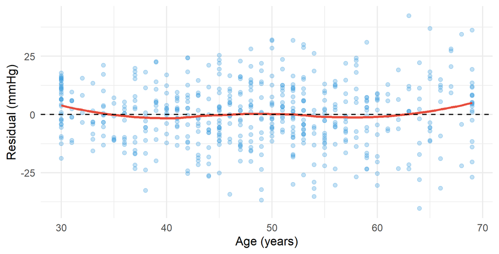

## A formal nudge: RESET test

```r
resettest(m, power = 2, type = "regressor")
```

```
    RESET test

data:  m
RESET = 2.7674, df1 = 3, df2 = 535, p-value = 0.04119
```

A small p-value suggests curvature somewhere — **but look at the plot** to see *where* and *how much*.

## What to do about non-linearity

```r
m_quad <- lm(sbp ~ salt_g + age + I(age^2) + bmi + sex + residence + education +
               tobacco + alcohol + phys_act, data = cc)
anova(m, m_quad)
```

```
Analysis of Variance Table

Model 1: sbp ~ salt_g + age + bmi + sex + residence + education + tobacco +
    alcohol + phys_act
Model 2: sbp ~ salt_g + age + I(age^2) + bmi + sex + residence + education +
    tobacco + alcohol + phys_act
  Res.Df   RSS Df Sum of Sq      F  Pr(>F)
1    538 98422
2    537 97336  1    1085.6 5.9891 0.01471 *
---
Signif. codes:  0 '***' 0.001 '**' 0.01 '*' 0.05 '.' 0.1 ' ' 1
```

- Add a **squared term** (`I(age^2)`) — the improvement is significant
- Better still for flexible shapes: **splines** (`splines::ns()`, `mgcv`) — mentioned in Session 6
- Or **categorise** (age bands) — simple but throws information away
- Or **transform** the predictor (e.g. log) when the curve is monotonic

# I — Independence

## Independence: what and how

**Means:** the residual of one person carries no information about another’s.

**Typically violated by:** people in the same **village / household / clinic**, **repeated measures** on the same person, **time series**.

**Check:** *by design first* (how were people sampled?), then plot residuals **by cluster** and estimate the **intraclass correlation**.

## In our data: people are clustered in 20 villages

```r
cc |>
  mutate(res = resid(m)) |>
  ggplot(aes(reorder(village, res, FUN = median), res)) +
  geom_boxplot(fill = "#d6eaf8") +
  geom_hline(yintercept = 0, linetype = "dashed", colour = col_red) +
  labs(x = "Village (ordered by median residual)", y = "Residual (mmHg)") +
  theme(axis.text.x = element_text(angle = 90, vjust = .5))
```

## In our data: people are clustered in 20 villages

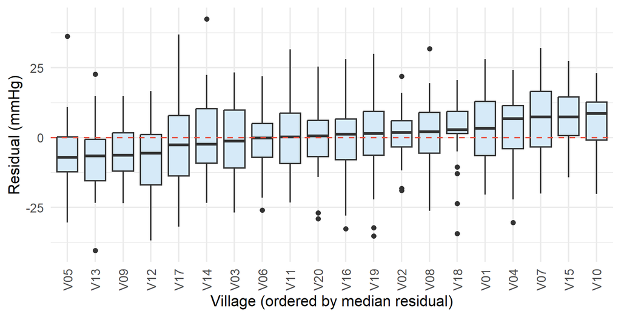

## How big is the clustering?

```r
a   <- anova(lm(resid(m) ~ factor(cc$village)))
msb <- a$`Mean Sq`[1]; msw <- a$`Mean Sq`[2]; k <- mean(table(cc$village))
icc <- (msb - msw) / (msb + (k - 1) * msw)
c(ICC = round(icc, 3), design_effect = round(1 + (k - 1) * icc, 2))
```

```
          ICC design_effect
        0.058         2.530
```

- **ICC ≈ 0.06**: about 6% of the residual variation lies *between* villages
- **Design effect ≈ 2.5**: for village-level exposures the standard errors may be too small by about √2.5 ≈ **1.6×**

## What to do about non-independence

In this workshop we only **detect and discuss** the village clustering — we do **not** model it.

- **Mixed models** with a random intercept per village (`lme4`)
- **GEE** (`geepack`) or **cluster-robust standard errors**
- **Survey-design methods** for complex samples such as NFHS (`survey`)
- At minimum: **report** the design, state the limitation, and be cautious with village-level predictors (e.g., residence)

# N — Normality

## Normality of residuals: what and how

**Means:** the **residuals** (not the outcome!) are roughly bell-shaped.

**Check:** **Q–Q plot** — points should follow the diagonal; a histogram; tests are secondary.

With n ≈ 550, the **central limit theorem** protects CIs for β. Normality matters most for **small samples** and **prediction intervals**.

## In our data

```r
augment(m) |>
  ggplot(aes(sample = .std.resid)) +
  stat_qq(alpha = .5, colour = col_blue) + stat_qq_line(colour = col_red, linewidth = 1) +
  labs(x = "Theoretical quantiles", y = "Standardised residuals")
```

```r
check_normality(m)
```

```
OK: residuals appear as normally distributed (p = 0.882).
```

## In our data

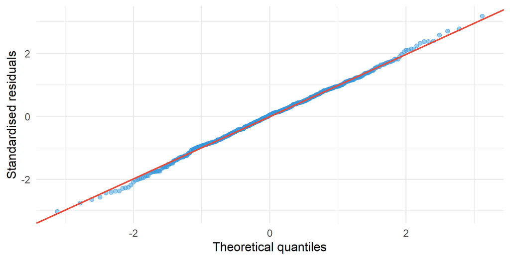

## If normality is badly violated

- Check for **outliers** or data errors first
- **Transform** the outcome (e.g., `log(sbp)`) — then interpret as % change
- **Bootstrap** the CIs (no normality assumption)
- **Robust regression** (`MASS::rlm`) or a different model for the outcome type

# E — Equal variance

## Homoscedasticity: what and how

**Means:** the spread of residuals is the **same** at every fitted value.

**Check:** residuals vs fitted — a **funnel** (fan) shape means variance grows with the mean. **Breusch–Pagan** test.

Biological outcomes often get **more variable at higher levels**: older adults vary more in BP.

## In our data: SBP varies more in older adults

```r
cc |>
  mutate(res = resid(m), age_band = cut(age, c(29, 39, 49, 59, 69), labels = c("30–39", "40–49", "50–59", "60–69"))) |>
  ggplot(aes(age_band, res)) +
  geom_boxplot(fill = "#d6eaf8") +
  geom_hline(yintercept = 0, linetype = "dashed", colour = col_red) +
  labs(x = "Age band", y = "Residual (mmHg)")
```

## In our data: SBP varies more in older adults

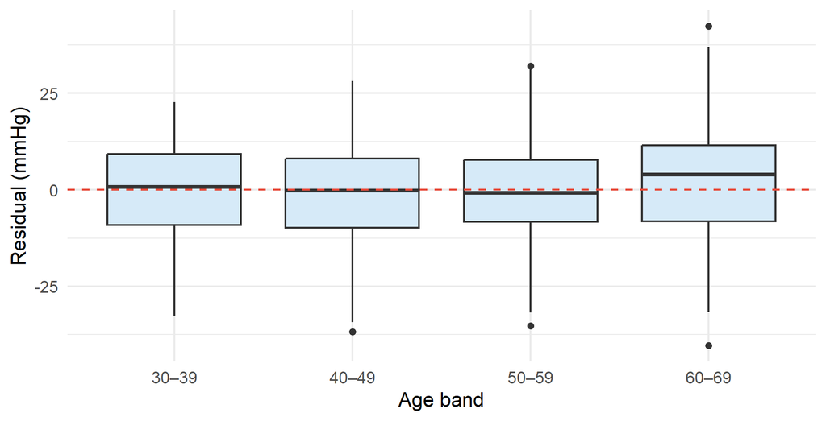

## Tests for non-constant variance

```r
check_heteroscedasticity(m)
bptest(m)
```

[output not shown]

```
    studentized Breusch-Pagan test

data:  m
BP = 22.89, df = 12, p-value = 0.02867
```

## What to do about unequal variance

```r
rob <- coeftest(m, vcov. = sandwich::vcovHC(m, type = "HC3"))
tibble(term = names(coef(m)),
       SE_usual  = round(summary(m)$coefficients[, 2], 3),
       SE_robust = round(rob[, 2], 3)) |> filter(term %in% c("salt_g", "age", "bmi", "sexMale"))
```

```
# A tibble: 4 × 3
  term    SE_usual SE_robust
  <chr>      <dbl>     <dbl>
1 salt_g     0.302     0.3
2 age        0.062     0.062
3 bmi        0.182     0.173
4 sexMale    1.29      1.30
```

- **Robust (sandwich) SEs**: same β, honest SEs — the easiest fix (`sandwich::vcovHC`)
- **Transform** the outcome (e.g., `log(sbp)`) or use **weighted least squares**
- Our violation is **mild**: conclusions do not change — but you should know and say so

# M — Multicollinearity

## Multicollinearity: what and how

**Means:** two or more predictors carry **nearly the same information**, so the model cannot tell their effects apart.

**Check:** correlation matrix and **VIF**.

**VIF** = how much a coefficient’s variance is inflated by correlation with the other predictors.

Rule of thumb: **> 5** worry, **> 10** serious.

## In our data: BMI and waist

```r
ggplot(cc, aes(bmi, waist)) +
  geom_point(alpha = .35, colour = col_blue) +
  geom_smooth(method = "lm", colour = col_red, formula = y ~ x) +
  annotate("text", x = 16, y = 125, hjust = 0, size = 6, label = paste0("r = ", round(cor(cc$bmi, cc$waist), 2))) +
  labs(x = "BMI (kg/m²)", y = "Waist (cm)")
```

## In our data: BMI and waist

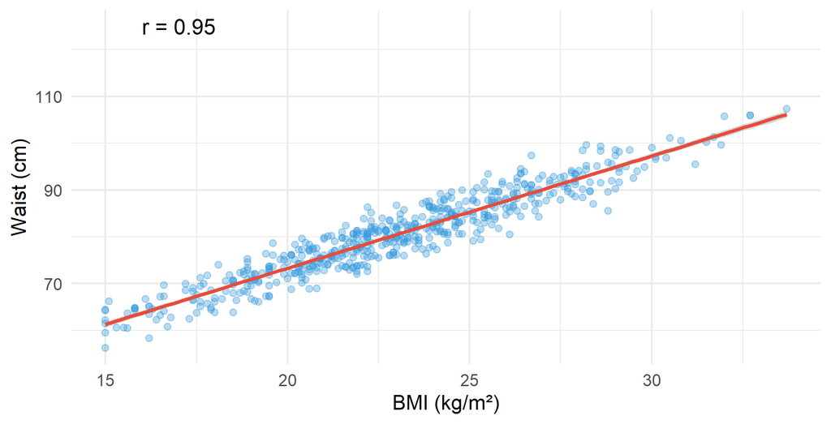

## VIF with both in the model

```r
m_both <- lm(sbp ~ salt_g + age + bmi + waist, data = cc)
check_collinearity(m_both)
```

```
# Check for Multicollinearity

Low Correlation

   Term  VIF    VIF 95% CI adj. VIF Tolerance Tolerance 95% CI
 salt_g 1.32 [1.21,  1.49]     1.15      0.76     [0.67, 0.82]
    age 1.14 [1.06,  1.30]     1.07      0.88     [0.77, 0.94]

High Correlation

  Term   VIF    VIF 95% CI adj. VIF Tolerance Tolerance 95% CI
   bmi 10.26 [8.79, 12.02]     3.20      0.10     [0.08, 0.11]
 waist 10.03 [8.59, 11.74]     3.17      0.10     [0.09, 0.12]
```

## What collinearity does to the estimates

```r
m_bmi <- lm(sbp ~ salt_g + age + bmi, data = cc)
bind_rows(`BMI alone` = tidy(m_bmi), `BMI + waist` = tidy(m_both), .id = "model") |>
  filter(term == "bmi") |> select(model, estimate, std.error, p.value) |>
  mutate(across(where(is.numeric), ~ signif(.x, 3)))
```

```
# A tibble: 2 × 4
  model       estimate std.error    p.value
  <chr>          <dbl>     <dbl>      <dbl>
1 BMI alone      0.814     0.182 0.00000957
2 BMI + waist   -0.537     0.528 0.31
```

With waist added, the **BMI coefficient shrinks toward zero (and can flip sign)** while its **SE roughly triples** — each variable “steals” the other’s effect.

## How to handle collinearity

- **Choose one** on clinical grounds (BMI for an exposure of interest; waist if central adiposity is the question) — **our fix**
- **Combine** into one measure (e.g., a ratio or first principal component)
- **Centre** predictors if the collinearity comes from polynomial or interaction terms
- **Penalised regression** (ridge/lasso — `glmnet`) when many correlated predictors
- Do **not** drop by p-value alone

# Influential points

## A few people can drive a result

```r
infl <- augment(m) |> mutate(row = row_number()) |> arrange(desc(.cooksd)) |> select(row, sbp, salt_g, age, .std.resid, .cooksd) |> head(5)
infl |> mutate(across(where(is.numeric), ~ round(.x, 3)))
```

```
# A tibble: 5 × 6
    row   sbp salt_g   age .std.resid .cooksd
  <dbl> <dbl>  <dbl> <dbl>      <dbl>   <dbl>
1   382   192    8.7    63       3.19   0.025
2   456   173    8      65       2.77   0.021
3   357   104    9      64      -3.02   0.019
4   337   109   12.7    49      -2.76   0.016
5   463   182    8.3    68       2.58   0.015
```

```r
check_outliers(m)
```

```
OK: No outliers detected.
- Based on the following method and threshold: cook (0.84).
- For variable: (Whole model)
```

- **Cook’s distance** flags people whose removal would change the fit most
- First **check data entry**; refit **with and without** them; report if conclusions change
- Do not delete people just because they are inconvenient

## All five assumptions on one slide

| Assumption | Check | In our data | What we do |
| --- | --- | --- | --- |
| Linearity | Residuals vs predictor, RESET | Slight age curvature | Add `age²` / spline |
| Independence | Design, residuals by cluster, ICC | Village ICC ≈ 0.06 | Mixed / GEE / robust SE (beyond today) |
| Normality | Q–Q plot | Acceptable | None needed (n large) |
| Equal variance | Residuals vs fitted, BP test | Variance rises with age (mild) | Robust SE |
| Collinearity | VIF | BMI & waist: VIF ≈ 10 | Keep one |

## 🔧 Switch to R — Lab 4

**File:** `regression-workshop/labs/lab4_assumptions.R`

- `check_model()` panel · residuals vs age
- normality and heteroscedasticity tests
- VIF with **waist + BMI** — then **fix it**
- Squared age term · robust SEs · village residuals

**Time:** 40 minutes · answer Q1–Q5 in the comments

## Self-check quiz (1/5)

The smoothed line through the residuals plotted against age is a shallow U-shape. What is the most direct fix?

- Add a squared age term to the model
- Drop age from the model entirely
- Log-transform the salt intake variable
- Remove the oldest participants from the data

## Self-check quiz (2/5)

BMI and waist (r = 0.95) both enter a model and each has a VIF of about 10. What is the best response?

- Keep both, since a high VIF does no harm
- Drop whichever variable has the larger p-value
- Log-transform the outcome and refit the model
- Keep one on clinical grounds, or combine them

## Self-check quiz (3/5)

Participants are sampled from 20 villages that share influences on blood pressure. Ignoring this mainly makes…

- the regression coefficients biased towards zero overall
- the residuals markedly non-normal within each village
- the R² smaller than it would otherwise be
- the standard errors too small for village-level traits

## Self-check quiz (4/5)

Residuals plotted against fitted values fan out like a funnel. Which assumption is violated? (two words)

## Self-check quiz (5/5)

When one predictor is regressed on all the others, R² = 0.90. What is its variance inflation factor? (whole number)

## Score and take-home

**Your score:**

- **LINE + M**: linearity, independence, normality, equal variance — plus collinearity
- **Plot first**, test second; tests are over-sensitive when n is large
- Match the **fix to the violation**: curve → add a term; variance → robust SE; clusters → mixed/GEE; collinearity → keep one
- **Report** what you checked and what you did about it

**Next:** Session 5 — logistic regression